# Лабораторная работа №1

Операционные системы

Бызова Мария Олеговна, НПИбд-01-23.

Российский университет дружбы народов, Москва, Россия

20. февраля 2024

## Цель работы

Целью данной работы является приобретение практических навыков установки операционной системы на виртуальную машину, настройки минимально необходимых для дальнейшей работы сервисов.

## Задание

1. Создание виртуальной машины.
2. Установка операционной системы.
3. Работа с операционной системой после установки.
4. Установка программного обеспечения для создания документации.
5. Дополнительные задания.

## Создание виртуальной машины

Cоздаю новую виртуальную машину, указываю ее имя, путь к папке машины по умолчанию меня устраивает, выбираю тип ОС и версию.Выбираю скачанный образ операционной системы. (рис. 1)

[figure not shown]

Создание виртуальной машины

## Создание виртуальной машины

Указываю объем основной памяти виртуальной машины размером 4096М (рис. 2)

[figure not shown]

Указание объёма памяти

## Создание виртуальной машины

Выбираю создание нового виртуального диска, задав конфигурацию жесткого диска: загрузочный VDI. Задаю размер диска - 80 ГБ, оставляю расположение жесткого диска по умолчанию, т.к. работаю на собственной технике и значение по умолчанию меня устраивает. (рис. 3)

[figure not shown]

Жёсткий диск

## Создание виртуальной машины

В качестве графического контроллера ставлю VMSVGA и включаю ускорение 3D (рис. 4)

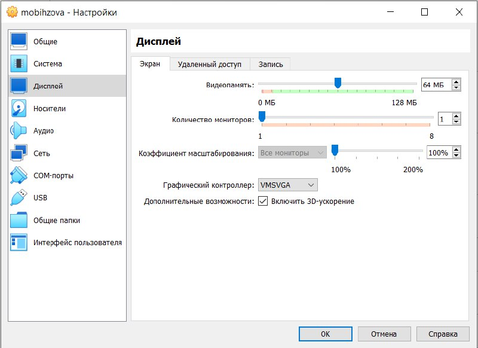

Графический контроллер и 3D-ускорение

## Создание виртуальной машины

Включаю общий буфер обмена и перетаскивание объектов между хостом и гостевой ОС. (рис. 5)

[figure not shown]

Общий буфер обмена и перетаскивание объектов между хостом и гостевой ОС

## Создание виртуальной машины

Включаю поддержку UEFI. (рис. 6)

[figure not shown]

Поддержка UEFI

## Установка операционной системы

Загружаю LiveCD. Появляется интерфейс начальной конфигурации. (рис. 7)

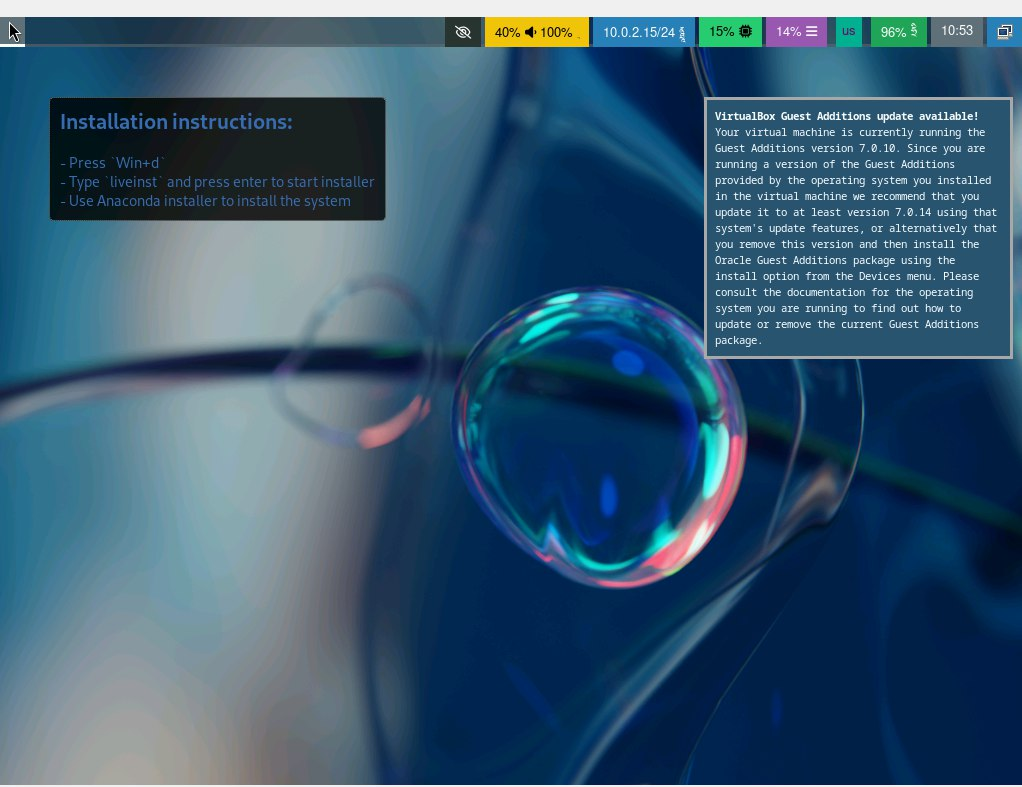

Интерфейс начальной конфигурации

## Установка операционной системы

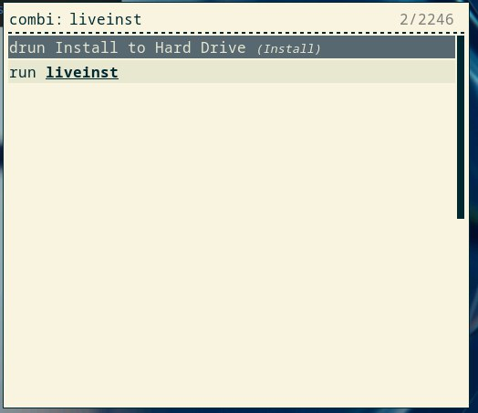

Запуск liveinst

## Установка операционной системы

Выбираю язык интерфейса и перехожу к настройкам установки операционной системы. Я не корректирую часовой пояс, раскладку клавиатуры и место установки ОС, так как в этом нет необходимости (рис. 9)

[figure not shown]

Выбор языка интерфейса

## Установка операционной системы

Установливаю имя и пароль для пользователя root. (рис. 10)

[figure not shown]

Установите имя и пароль для моего пользователя.(рис. 10)

[figure not shown]

Создание пользователя

## Установка операционной системы

Далее операционная система устанавливается. После установки нажимаю “Завершить установку” (рис. 11)

[figure not shown]

Завершение установки операционной системы

## Установка операционной системы

Диск не отключался автоматически, поэтому отключаю носитель информации с образом (рис. 12)

[figure not shown]

Просмотр и отключение оптического диска

## Работа с операционной системой после установки

Запускаю виртуальную машину. Вхожу в ОС под заданной мной при установке учетной записью (рис. 13)

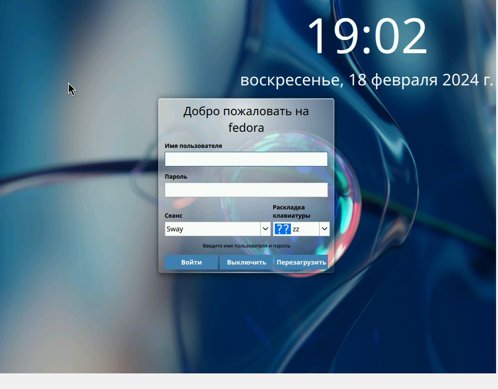

Вход в ОС

## Работа с операционной системой после установки

Нажимаю WIN+ENTER для запуска терминала и переключаюсь на роль суперпользователя. Обновляю все пакеты (рис. 14)

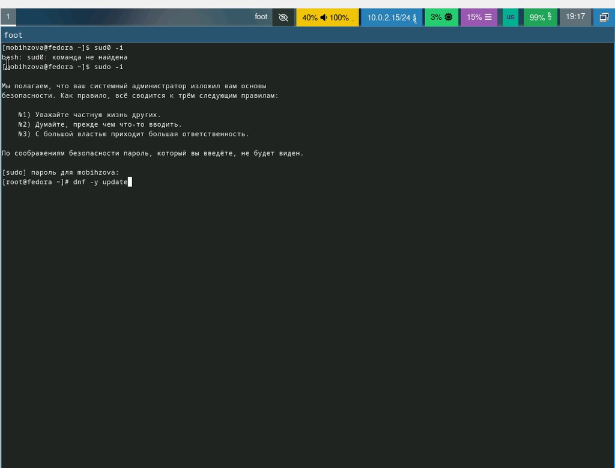

Обновление пакетов

## Работа с операционной системой после установки

Устанавливаю программы для удобства работы в консоли: tmux для открытия нескольких “вкладок” в одном терминале, mc в качестве файлового менеджера в терминале (рис. 15)

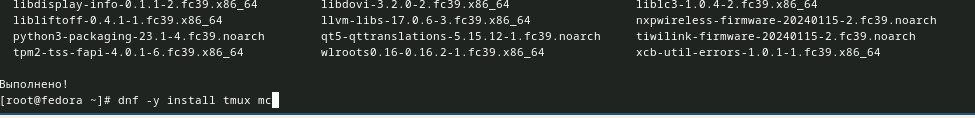

Установка tmux и mc

## Работа с операционной системой после установки

Устанавливаю программы для автоматического обновления (рис. 16)

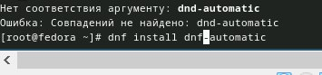

Установка программного обеспечения для автоматического обновления

## Работа с операционной системой после установки

Запускаю таймер (рис. 17)

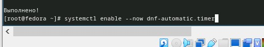

Запуск таймера

## Работа с операционной системой после установки

Переместившись в директорию /etc/selinux, открываю mc, ищу нужный файл. Изменяю открытый файл: SELINUX=enforcing заменяю SELINUX=permissive, после чего перезагружаю виртуальную машину (рис. 18)

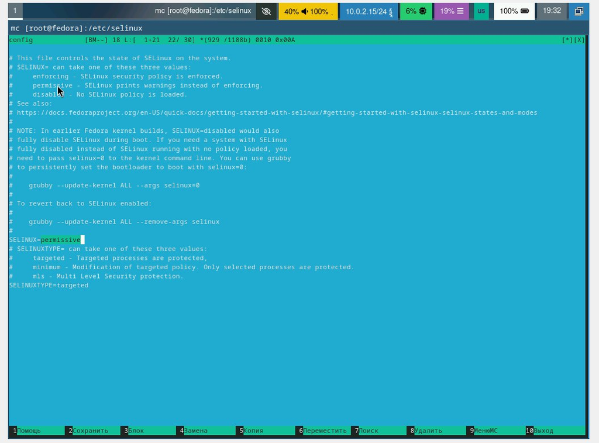

Изменение файла

## Работа с операционной системой после установки

Снова вхожу в ОС, снова запускаю терминальный мультиплексор, переключаюсь на роль суперпользователя и устанавливаю средства разработки (рис. 19)

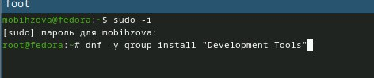

Установка средств разработки

## Работа с операционной системой после установки

Устанавливаю пакет dkms (рис. 20)

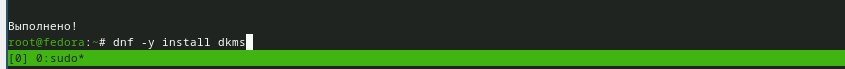

Устанока пакета dkms

## Работа с операционной системой после установки

В меню виртуальной машины подключаю образ диска гостевой ОС (рис. 21)

[figure not shown]

Подключение образа диска гостей ОС

## Работа с операционной системой после установки

Примонтирую диск и установлю драйвера, после чего перезагружу виртуальную машину (рис. 22)

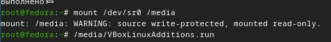

Примонтировка диска и установка драйверов

## Работа с операционной системой после установки

Вхожу в ОС под заданной мной при установке учётной записью, запускаю терминальный мультиплексор tmux, создаю конфигурационный файл ~/.config/sway/config.d/95-system-keyboard-config.conf (рис. 23)

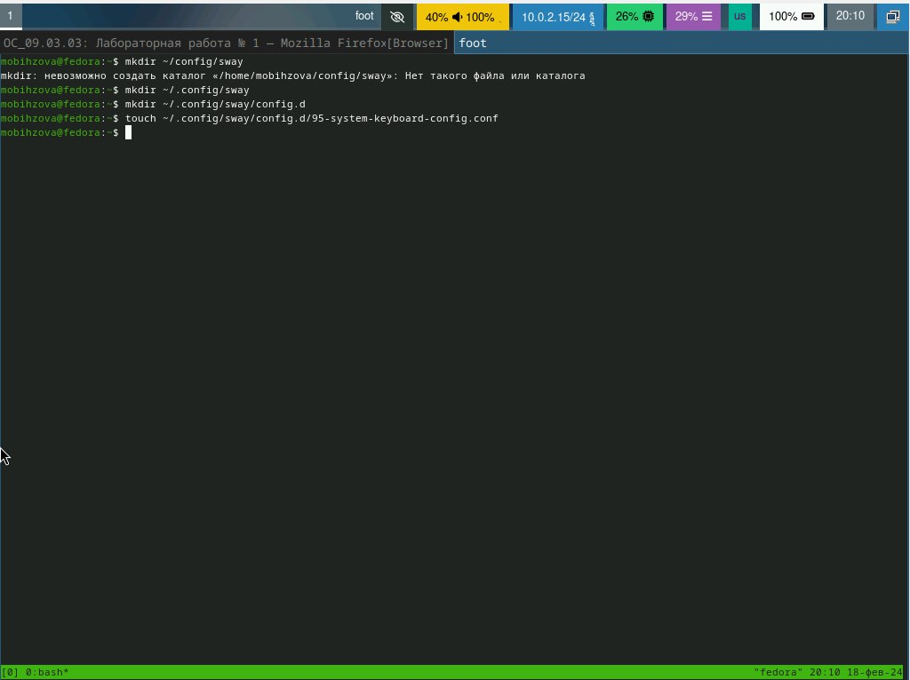

Создание конфигурационного файла

## Работа с операционной системой после установки

Отредактирую конфигурационный файл ~/.config/sway/config.d/95-system-keyboard-config.conf (рис. 24)

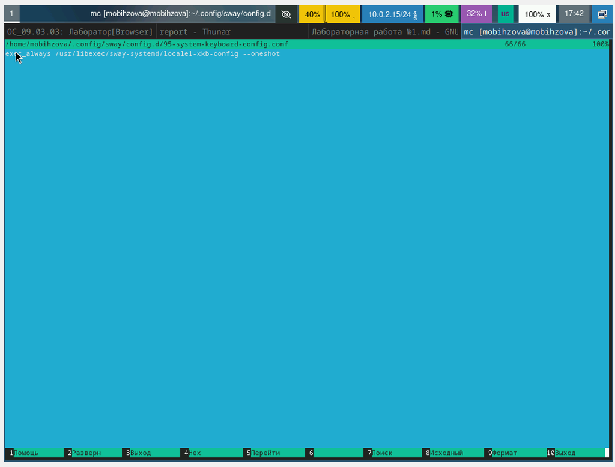

Изменение конфигурационного файла

## Работа с операционной системой после установки

Переключаюсь на роль супер-пользователя sudo, отредактирую конфигурационный файл /etc/X11/xorg.conf.d/00-keyboard.conf, после чего перезагружу виртуальную машину (рис. 25)

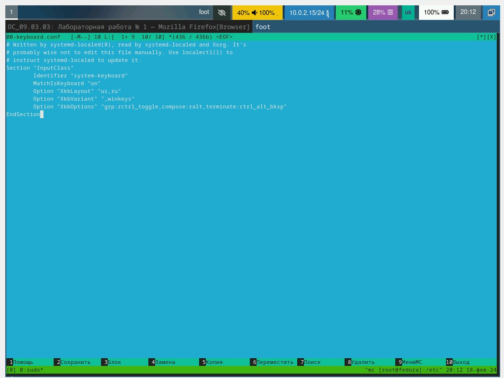

Изменение конфигурационного файла

## Работа с операционной системой после установки

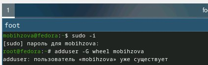

## Работа с операционной системой после установки

Задаю пароль для пользователя (рис. 27)

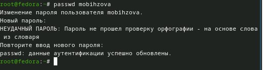

Создание пароля

## Работа с операционной системой после установки

Установлю имя хоста, Проверю, что имя хоста установлено верно (рис. 28)

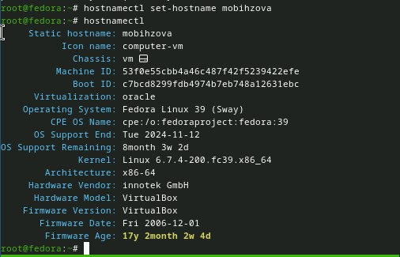

Установка имени хоста

## Работа с операционной системой после установки

Внутри виртуальной машины добавлю своего пользователя в группу vboxsf (рис. 29)

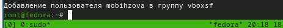

Добавление пользователя

## Работа с операционной системой после установки

В хостовой системе подключаю разделяемую общую папку, после чего перезагружаю систему (рис. 30)

[figure not shown]

Подключение общей папки